# Parent material and climate interact to control soil carbon dynamics on timescales from years to centuries

## Marginal mean trends: 2001-2019

The next set of plots show least-square mean estimates of trends and associated confidence intervals for each parent material, within climate groups, over the time period 2001 to 2019. Plots are shown for each depth increment. Raw data are shown as points.

Following each plot I show the contrasts for the slope estimates within parent material and climate groups. The first set of numbers show marginal means estimated within groups; second set of numbers show the contrasts, i.e. are the trends over time significantly different between different parent materials or climate conditions?

### Bulk soil

#### 0-10cm

##### Interaction plots

> **Fig. 2. Temporal trends in bulk soil $\Delta$<sup>14</sup>C by parent material (0-10cm)**

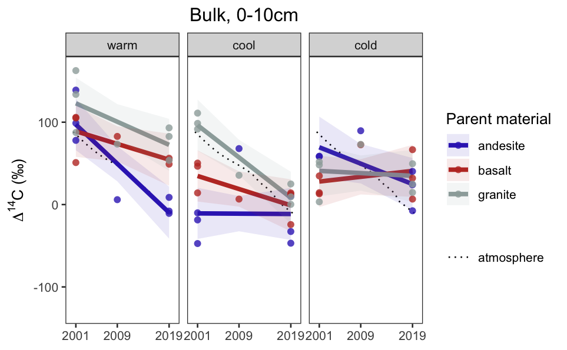

```r
# PM | ECO
emmip.plot.fx(lyr_bot = 10,
              Type = "Bulk",
              var = "PM",
              interact_var = "ECO")
```

##### Trends & Contrasts

> **Table 7. Bulk soil, 0-10cm: Parent material trends within climate**

```r
print("Interactions, PM | ECO")
```

```
[1] "Interactions, PM | ECO"
```

```r
emtrends(blk.PMeco.10.lm, pairwise ~ PM | ECO, var = "year")
```

```
$emtrends
ECO = warm:
 PM       year.trend   SE df lower.CL upper.CL
 andesite    -5.9398 1.27 44    -8.49   -3.387
 basalt      -1.9159 1.27 44    -4.47    0.637
 granite     -2.8014 1.27 44    -5.35   -0.249

ECO = cool:
 PM       year.trend   SE df lower.CL upper.CL
 andesite    -0.0398 1.27 44    -2.59    2.513
 basalt      -1.9819 1.27 44    -4.53    0.571
 granite     -4.8933 1.27 44    -7.45   -2.340

ECO = cold:
 PM       year.trend   SE df lower.CL upper.CL
 andesite    -2.4840 1.41 44    -5.32    0.349
 basalt       0.7185 1.27 44    -1.83    3.271
 granite     -0.3370 1.27 44    -2.89    2.216

Confidence level used: 0.95

$contrasts
ECO = warm:
 contrast           estimate   SE df t.ratio p.value
 andesite - basalt    -4.024 1.79 44 -2.246  0.0745
 andesite - granite   -3.138 1.79 44 -1.752  0.1978
 basalt - granite      0.885 1.79 44  0.494  0.8744

ECO = cool:
 contrast           estimate   SE df t.ratio p.value
 andesite - basalt     1.942 1.79 44  1.084  0.5288
 andesite - granite    4.853 1.79 44  2.709  0.0254
 basalt - granite      2.911 1.79 44  1.625  0.2459

ECO = cold:
 contrast           estimate   SE df t.ratio p.value
 andesite - basalt    -3.203 1.89 44 -1.692  0.2194
 andesite - granite   -2.147 1.89 44 -1.135  0.4982
 basalt - granite      1.055 1.79 44  0.589  0.8266

P value adjustment: tukey method for comparing a family of 3 estimates
```

> **Table 8. Bulk soil, 0-10cm: Climate trends within parent material**

```r
print("Interactions, ECO | PM")
```

```
[1] "Interactions, ECO | PM"
```

```r
emtrends(blk.PMeco.10.lm, pairwise ~ ECO | PM, var = "year")
```

```
$emtrends
PM = andesite:
 ECO  year.trend   SE df lower.CL upper.CL
 warm    -5.9398 1.27 44    -8.49   -3.387
 cool    -0.0398 1.27 44    -2.59    2.513
 cold    -2.4840 1.41 44    -5.32    0.349

PM = basalt:
 ECO  year.trend   SE df lower.CL upper.CL
 warm    -1.9159 1.27 44    -4.47    0.637
 cool    -1.9819 1.27 44    -4.53    0.571
 cold     0.7185 1.27 44    -1.83    3.271

PM = granite:
 ECO  year.trend   SE df lower.CL upper.CL
 warm    -2.8014 1.27 44    -5.35   -0.249
 cool    -4.8933 1.27 44    -7.45   -2.340
 cold    -0.3370 1.27 44    -2.89    2.216

Confidence level used: 0.95

$contrasts
PM = andesite:
 contrast    estimate   SE df t.ratio p.value
 warm - cool   -5.900 1.79 44 -3.293  0.0055
 warm - cold   -3.456 1.89 44 -1.826  0.1729
 cool - cold    2.444 1.89 44  1.292  0.4073

PM = basalt:
 contrast    estimate   SE df t.ratio p.value
 warm - cool    0.066 1.79 44  0.037  0.9993
 warm - cold   -2.634 1.79 44 -1.471  0.3147
 cool - cold   -2.700 1.79 44 -1.507  0.2973

PM = granite:
 contrast    estimate   SE df t.ratio p.value
 warm - cool    2.092 1.79 44  1.168  0.4785
 warm - cold   -2.464 1.79 44 -1.376  0.3622
 cool - cold   -4.556 1.79 44 -2.543  0.0380

P value adjustment: tukey method for comparing a family of 3 estimates
```

#### 10-20cm

##### Interaction plots

> **Fig. 3. Temporal trends in bulk soil $\Delta$<sup>14</sup>C by parent material (10-20cm)**

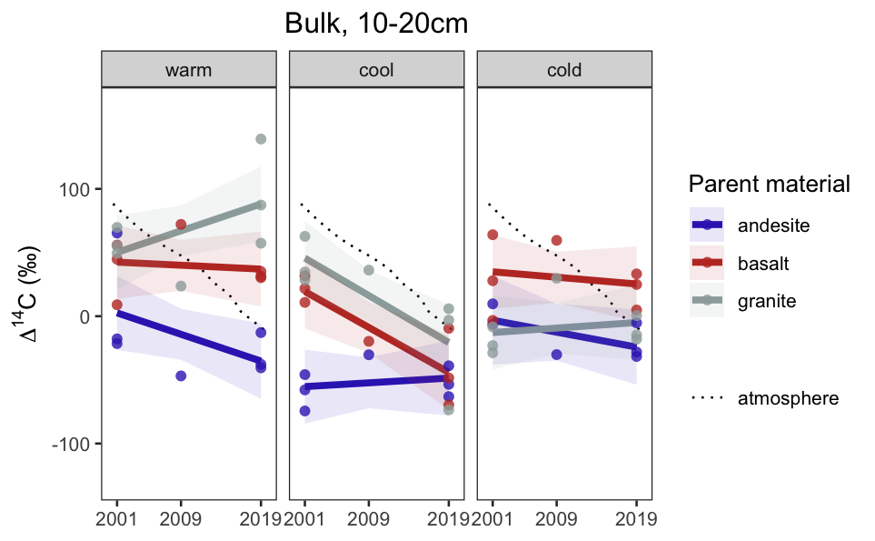

```r
# PM | ECO
emmip.plot.fx(lyr_bot = 20,
              Type = "Bulk",
              var = "PM",
              interact_var = "ECO")
```

##### Trends & Contrasts

> **Table 9. Bulk soil, 10-20cm: Parent material trends within climate**

```r
print("Interactions, PM | ECO")
```

```
[1] "Interactions, PM | ECO"
```

```r
emtrends(blk.PMeco.20.lm, pairwise ~ PM | ECO, var = "year")
```

```
$emtrends
ECO = warm:
 PM       year.trend   SE df lower.CL upper.CL
 andesite     -2.103 1.18 44   -4.488    0.283
 basalt       -0.304 1.18 44   -2.689    2.081
 granite       2.111 1.18 44   -0.274    4.496

ECO = cool:
 PM       year.trend   SE df lower.CL upper.CL
 andesite      0.372 1.18 44   -2.014    2.757
 basalt       -3.531 1.18 44   -5.917   -1.146
 granite      -3.685 1.18 44   -6.070   -1.300

ECO = cold:
 PM       year.trend   SE df lower.CL upper.CL
 andesite     -1.172 1.31 44   -3.819    1.475
 basalt       -0.533 1.18 44   -2.918    1.853
 granite       0.437 1.18 44   -1.949    2.822

Confidence level used: 0.95

$contrasts
ECO = warm:
 contrast           estimate   SE df t.ratio p.value
 andesite - basalt    -1.799 1.67 44 -1.075  0.5347
 andesite - granite   -4.214 1.67 44 -2.518  0.0404
 basalt - granite     -2.415 1.67 44 -1.443  0.3282

ECO = cool:
 contrast           estimate   SE df t.ratio p.value
 andesite - basalt     3.903 1.67 44  2.332  0.0618
 andesite - granite    4.057 1.67 44  2.424  0.0502
 basalt - granite      0.154 1.67 44  0.092  0.9954

ECO = cold:
 contrast           estimate   SE df t.ratio p.value
 andesite - basalt    -0.640 1.77 44 -0.362  0.9305
 andesite - granite   -1.609 1.77 44 -0.910  0.6369
 basalt - granite     -0.969 1.67 44 -0.579  0.8319

P value adjustment: tukey method for comparing a family of 3 estimates
```

> **Table 10. Bulk soil, 10-20cm: Climate trends within parent material**

```r
print("Interactions, ECO | PM")
```

```
[1] "Interactions, ECO | PM"
```

```r
emtrends(blk.PMeco.20.lm, pairwise ~ ECO | PM, var = "year")
```

```
$emtrends
PM = andesite:
 ECO  year.trend   SE df lower.CL upper.CL
 warm     -2.103 1.18 44   -4.488    0.283
 cool      0.372 1.18 44   -2.014    2.757
 cold     -1.172 1.31 44   -3.819    1.475

PM = basalt:
 ECO  year.trend   SE df lower.CL upper.CL
 warm     -0.304 1.18 44   -2.689    2.081
 cool     -3.531 1.18 44   -5.917   -1.146
 cold     -0.533 1.18 44   -2.918    1.853

PM = granite:
 ECO  year.trend   SE df lower.CL upper.CL
 warm      2.111 1.18 44   -0.274    4.496
 cool     -3.685 1.18 44   -6.070   -1.300
 cold      0.437 1.18 44   -1.949    2.822

Confidence level used: 0.95

$contrasts
PM = andesite:
 contrast    estimate   SE df t.ratio p.value
 warm - cool   -2.474 1.67 44 -1.478  0.3110
 warm - cold   -0.930 1.77 44 -0.526  0.8589
 cool - cold    1.544 1.77 44  0.873  0.6598

PM = basalt:
 contrast    estimate   SE df t.ratio p.value
 warm - cool    3.227 1.67 44  1.928  0.1428
 warm - cold    0.229 1.67 44  0.137  0.9898
 cool - cold   -2.999 1.67 44 -1.792  0.1842

PM = granite:
 contrast    estimate   SE df t.ratio p.value
 warm - cool    5.796 1.67 44  3.463  0.0034
 warm - cold    1.674 1.67 44  1.000  0.5806
 cool - cold   -4.122 1.67 44 -2.463  0.0459

P value adjustment: tukey method for comparing a family of 3 estimates
```

#### 20-30cm

##### Interaction plots

> **Fig. 4. Temporal trends in bulk soil $\Delta$<sup>14</sup>C by parent material (20-30cm)**

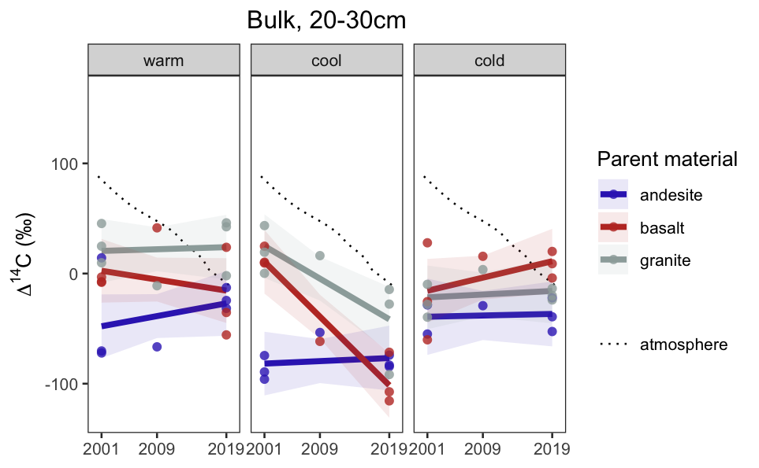

```r
# PM | ECO
emmip.plot.fx(lyr_bot = 30,
              Type = "Bulk",
              var = "PM",
              interact_var = "ECO")
```

##### Trends & Contrasts

> **Table 11. Bulk soil, 20-30cm: Parent material trends within climate**

```r
print("Interactions, PM | ECO")
```

```
[1] "Interactions, PM | ECO"
```

```r
emtrends(blk.PMeco.30.lm, pairwise ~ PM | ECO, var = "year")
```

```
$emtrends
ECO = warm:
 PM       year.trend   SE df lower.CL upper.CL
 andesite      1.155 1.18 44   -1.222     3.53
 basalt       -0.999 1.18 44   -3.376     1.38
 granite       0.189 1.18 44   -2.188     2.57

ECO = cool:
 PM       year.trend   SE df lower.CL upper.CL
 andesite      0.280 1.18 44   -2.097     2.66
 basalt       -6.233 1.18 44   -8.611    -3.86
 granite      -3.691 1.18 44   -6.068    -1.31

ECO = cold:
 PM       year.trend   SE df lower.CL upper.CL
 andesite      0.142 1.31 44   -2.496     2.78
 basalt        1.491 1.18 44   -0.886     3.87
 granite       0.322 1.18 44   -2.055     2.70

Confidence level used: 0.95

$contrasts
ECO = warm:
 contrast           estimate   SE df t.ratio p.value
 andesite - basalt     2.154 1.67 44  1.291  0.4075
 andesite - granite    0.967 1.67 44  0.579  0.8318
 basalt - granite     -1.188 1.67 44 -0.712  0.7578

ECO = cool:
 contrast           estimate   SE df t.ratio p.value
 andesite - basalt     6.513 1.67 44  3.905  0.0009
 andesite - granite    3.971 1.67 44  2.381  0.0554
 basalt - granite     -2.542 1.67 44 -1.524  0.2897

ECO = cold:
 contrast           estimate   SE df t.ratio p.value
 andesite - basalt    -1.349 1.76 44 -0.766  0.7258
 andesite - granite   -0.180 1.76 44 -0.102  0.9942
 basalt - granite      1.169 1.67 44  0.701  0.7643

P value adjustment: tukey method for comparing a family of 3 estimates
```

> **Table 12. Bulk soil, 20-30cm: Climate trends within parent material**

```r
print("Interactions, ECO | PM")
```

```
[1] "Interactions, ECO | PM"
```

```r
emtrends(blk.PMeco.30.lm, pairwise ~ ECO | PM, var = "year")
```

```
$emtrends
PM = andesite:
 ECO  year.trend   SE df lower.CL upper.CL
 warm      1.155 1.18 44   -1.222     3.53
 cool      0.280 1.18 44   -2.097     2.66
 cold      0.142 1.31 44   -2.496     2.78

PM = basalt:
 ECO  year.trend   SE df lower.CL upper.CL
 warm     -0.999 1.18 44   -3.376     1.38
 cool     -6.233 1.18 44   -8.611    -3.86
 cold      1.491 1.18 44   -0.886     3.87

PM = granite:
 ECO  year.trend   SE df lower.CL upper.CL
 warm      0.189 1.18 44   -2.188     2.57
 cool     -3.691 1.18 44   -6.068    -1.31
 cold      0.322 1.18 44   -2.055     2.70

Confidence level used: 0.95

$contrasts
PM = andesite:
 contrast    estimate   SE df t.ratio p.value
 warm - cool    0.875 1.67 44  0.525  0.8597
 warm - cold    1.014 1.76 44  0.575  0.8339
 cool - cold    0.139 1.76 44  0.079  0.9966

PM = basalt:
 contrast    estimate   SE df t.ratio p.value
 warm - cool    5.234 1.67 44  3.138  0.0084
 warm - cold   -2.490 1.67 44 -1.492  0.3043
 cool - cold   -7.724 1.67 44 -4.630  0.0001

PM = granite:
 contrast    estimate   SE df t.ratio p.value
 warm - cool    3.880 1.67 44  2.326  0.0626
 warm - cold   -0.133 1.67 44 -0.080  0.9965
 cool - cold   -4.013 1.67 44 -2.406  0.0523

P value adjustment: tukey method for comparing a family of 3 estimates
```

### Respired CO<sub>2</sub>

#### 0-10cm

##### Interaction plots

> **Fig. 5. Temporal trends in respired $\Delta$<sup>14</sup>C-CO<sub>2</sub> by parent material (0-10cm)**

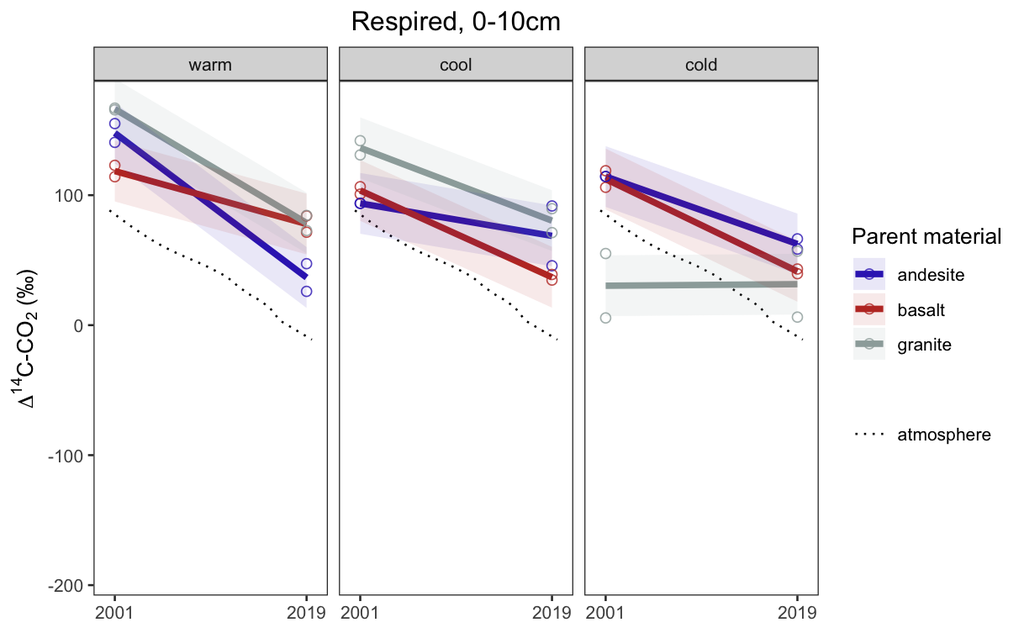

```r
# PM | ECO
emmip.plot.fx(lyr_bot = 10,
              Type = "Respired",
              var = "PM",
              interact_var = "ECO")
```

##### Trends & Contrasts

> **Table 13. Respired CO<sub>2</sub>, 0-10cm: Parent material trends within climate**

```r
print("Interactions, PM | ECO")
```

```
[1] "Interactions, PM | ECO"
```

```r
emtrends(inc.PMeco.10.lm, pairwise ~ PM | ECO, var = "year")
```

```
$emtrends
ECO = warm:
 PM       year.trend    SE df lower.CL upper.CL
 andesite     -6.177 0.875 18    -8.01   -4.340
 basalt       -2.265 0.875 18    -4.10   -0.427
 granite      -4.873 0.875 18    -6.71   -3.035

ECO = cool:
 PM       year.trend    SE df lower.CL upper.CL
 andesite     -1.390 0.875 18    -3.23    0.448
 basalt       -3.711 0.875 18    -5.55   -1.873
 granite      -3.114 0.875 18    -4.95   -1.276

ECO = cold:
 PM       year.trend    SE df lower.CL upper.CL
 andesite     -2.884 0.875 18    -4.72   -1.046
 basalt       -3.946 0.875 18    -5.78   -2.108
 granite       0.067 0.875 18    -1.77    1.905

Results are averaged over the levels of: year
Confidence level used: 0.95

$contrasts
ECO = warm:
 contrast           estimate   SE df t.ratio p.value
 andesite - basalt    -3.913 1.24 18 -3.163  0.0142
 andesite - granite   -1.304 1.24 18 -1.054  0.5535
 basalt - granite      2.608 1.24 18  2.109  0.1161

ECO = cool:
 contrast           estimate   SE df t.ratio p.value
 andesite - basalt     2.321 1.24 18  1.877  0.1741
 andesite - granite    1.724 1.24 18  1.394  0.3648
 basalt - granite     -0.597 1.24 18 -0.483  0.8803

ECO = cold:
 contrast           estimate   SE df t.ratio p.value
 andesite - basalt     1.062 1.24 18  0.859  0.6723
 andesite - granite   -2.951 1.24 18 -2.385  0.0693
 basalt - granite     -4.013 1.24 18 -3.244  0.0119

Results are averaged over the levels of: year
P value adjustment: tukey method for comparing a family of 3 estimates
```

> **Table 14. Respired CO<sub>2</sub>, 0-10cm: Climate trends within parent material**

```r
print("Interactions, ECO | PM")
```

```
[1] "Interactions, ECO | PM"
```

```r
emtrends(inc.PMeco.10.lm, pairwise ~ ECO | PM, var = "year")
```

```
$emtrends
PM = andesite:
 ECO  year.trend    SE df lower.CL upper.CL
 warm     -6.177 0.875 18    -8.01   -4.340
 cool     -1.390 0.875 18    -3.23    0.448
 cold     -2.884 0.875 18    -4.72   -1.046

PM = basalt:
 ECO  year.trend    SE df lower.CL upper.CL
 warm     -2.265 0.875 18    -4.10   -0.427
 cool     -3.711 0.875 18    -5.55   -1.873
 cold     -3.946 0.875 18    -5.78   -2.108

PM = granite:
 ECO  year.trend    SE df lower.CL upper.CL
 warm     -4.873 0.875 18    -6.71   -3.035
 cool     -3.114 0.875 18    -4.95   -1.276
 cold      0.067 0.875 18    -1.77    1.905

Results are averaged over the levels of: year
Confidence level used: 0.95

$contrasts
PM = andesite:
 contrast    estimate   SE df t.ratio p.value
 warm - cool   -4.788 1.24 18 -3.870  0.0031
 warm - cold   -3.294 1.24 18 -2.663  0.0401
 cool - cold    1.494 1.24 18  1.208  0.4638

PM = basalt:
 contrast    estimate   SE df t.ratio p.value
 warm - cool    1.446 1.24 18  1.169  0.4859
 warm - cold    1.681 1.24 18  1.359  0.3823
 cool - cold    0.235 1.24 18  0.190  0.9803

PM = granite:
 contrast    estimate   SE df t.ratio p.value
 warm - cool   -1.759 1.24 18 -1.422  0.3509
 warm - cold   -4.940 1.24 18 -3.994  0.0023
 cool - cold   -3.181 1.24 18 -2.571  0.0481

Results are averaged over the levels of: year
P value adjustment: tukey method for comparing a family of 3 estimates
```

#### 10-20cm

##### Interaction plots

> **Fig. 6. Temporal trends in respired $\Delta$<sup>14</sup>C-CO<sub>2</sub> by parent material (10-20cm)**

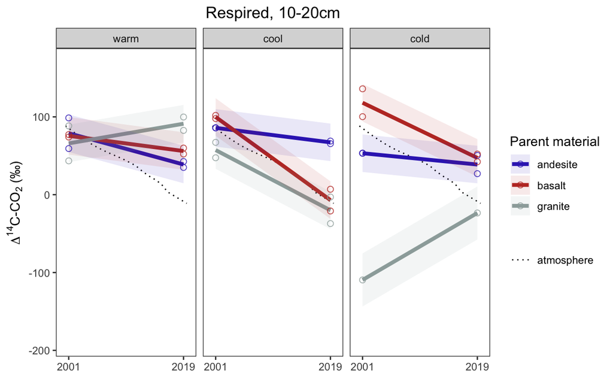

```r
# PM | ECO
emmip.plot.fx(lyr_bot = 20,
              Type = "Respired",
              var = "PM",
              interact_var = "ECO")
```

##### Trends & Contrasts

> **Table 15. Respired CO<sub>2</sub>, 10-20cm: Parent material trends within climate**

```r
print("Interactions, PM | ECO")
```

```
[1] "Interactions, PM | ECO"
```

```r
emtrends(inc.PMeco.20.lm, pairwise ~ PM | ECO, var = "year")
```

```
$emtrends
ECO = warm:
 PM       year.trend    SE df lower.CL upper.CL
 andesite     -2.231 0.894 16   -4.126   -0.337
 basalt       -1.086 0.894 16   -2.981    0.808
 granite       1.404 0.894 16   -0.491    3.298

ECO = cool:
 PM       year.trend    SE df lower.CL upper.CL
 andesite     -1.036 0.894 16   -2.930    0.859
 basalt       -5.933 0.894 16   -7.827   -4.038
 granite      -4.299 0.894 16   -6.194   -2.405

ECO = cold:
 PM       year.trend    SE df lower.CL upper.CL
 andesite     -0.808 0.894 16   -2.703    1.086
 basalt       -3.939 0.894 16   -5.833   -2.044
 granite       4.780 1.264 16    2.101    7.459

Results are averaged over the levels of: year
Confidence level used: 0.95

$contrasts
ECO = warm:
 contrast           estimate   SE df t.ratio p.value
 andesite - basalt     -1.15 1.26 16 -0.906  0.6444
 andesite - granite    -3.63 1.26 16 -2.876  0.0280
 basalt - granite      -2.49 1.26 16 -1.970  0.1519

ECO = cool:
 contrast           estimate   SE df t.ratio p.value
 andesite - basalt      4.90 1.26 16  3.875  0.0036
 andesite - granite     3.26 1.26 16  2.582  0.0498
 basalt - granite      -1.63 1.26 16 -1.293  0.4194

ECO = cold:
 contrast           estimate   SE df t.ratio p.value
 andesite - basalt      3.13 1.26 16  2.477  0.0609
 andesite - granite    -5.59 1.55 16 -3.610  0.0063
 basalt - granite      -8.72 1.55 16 -5.633  0.0001

Results are averaged over the levels of: year
P value adjustment: tukey method for comparing a family of 3 estimates
```

> **Table 16. Respired CO<sub>2</sub>, 10-20cm: Climate trends within parent material**

```r
print("Interactions, ECO | PM")
```

```
[1] "Interactions, ECO | PM"
```

```r
emtrends(inc.PMeco.20.lm, pairwise ~ ECO | PM, var = "year")
```

```
$emtrends
PM = andesite:
 ECO  year.trend    SE df lower.CL upper.CL
 warm     -2.231 0.894 16   -4.126   -0.337
 cool     -1.036 0.894 16   -2.930    0.859
 cold     -0.808 0.894 16   -2.703    1.086

PM = basalt:
 ECO  year.trend    SE df lower.CL upper.CL
 warm     -1.086 0.894 16   -2.981    0.808
 cool     -5.933 0.894 16   -7.827   -4.038
 cold     -3.939 0.894 16   -5.833   -2.044

PM = granite:
 ECO  year.trend    SE df lower.CL upper.CL
 warm      1.404 0.894 16   -0.491    3.298
 cool     -4.299 0.894 16   -6.194   -2.405
 cold      4.780 1.264 16    2.101    7.459

Results are averaged over the levels of: year
Confidence level used: 0.95

$contrasts
PM = andesite:
 contrast    estimate   SE df t.ratio p.value
 warm - cool   -1.196 1.26 16 -0.946  0.6201
 warm - cold   -1.423 1.26 16 -1.126  0.5126
 cool - cold   -0.228 1.26 16 -0.180  0.9823

PM = basalt:
 contrast    estimate   SE df t.ratio p.value
 warm - cool    4.847 1.26 16  3.835  0.0039
 warm - cold    2.852 1.26 16  2.257  0.0917
 cool - cold   -1.994 1.26 16 -1.578  0.2833

PM = granite:
 contrast    estimate   SE df t.ratio p.value
 warm - cool    5.703 1.26 16  4.512  0.0010
 warm - cold   -3.376 1.55 16 -2.181  0.1051
 cool - cold   -9.079 1.55 16 -5.866  0.0001

Results are averaged over the levels of: year
P value adjustment: tukey method for comparing a family of 3 estimates
```

#### 20-30cm

##### Interaction plots

> **Fig. 7. Temporal trends in respired $\Delta$<sup>14</sup>C-CO<sub>2</sub> by parent material (20-30cm)**

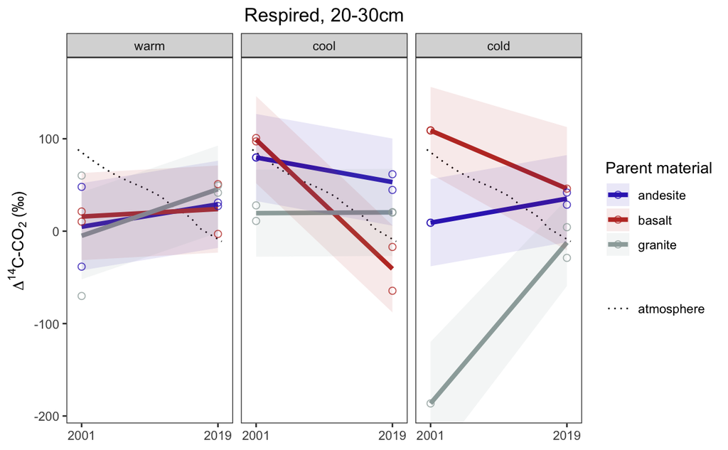

```r
# PM | ECO
emmip.plot.fx(lyr_bot = 30,
              Type = "Respired",
              var = "PM",
              interact_var = "ECO")
```

##### Trends & Contrasts

> **Table 17. Respired CO<sub>2</sub>, 20-30cm: Parent material trends within climate**

```r
print("Interactions, PM | ECO")
```

```
[1] "Interactions, PM | ECO"
```

```r
emtrends(inc.PMeco.30.lm, pairwise ~ PM | ECO, var = "year")
```

```
$emtrends
ECO = warm:
 PM       year.trend   SE df lower.CL upper.CL
 andesite     1.3490 1.75 16   -2.355     5.05
 basalt       0.4534 1.75 16   -3.250     4.16
 granite      2.8025 1.75 16   -0.901     6.51

ECO = cool:
 PM       year.trend   SE df lower.CL upper.CL
 andesite    -1.4790 1.75 16   -5.183     2.22
 basalt      -7.7646 1.75 16  -11.468    -4.06
 granite      0.0487 1.75 16   -3.655     3.75

ECO = cold:
 PM       year.trend   SE df lower.CL upper.CL
 andesite     1.4481 1.75 16   -2.256     5.15
 basalt      -3.4986 2.14 16   -8.035     1.04
 granite      9.6728 2.14 16    5.137    14.21

Results are averaged over the levels of: year
Confidence level used: 0.95

$contrasts
ECO = warm:
 contrast           estimate   SE df t.ratio p.value
 andesite - basalt     0.896 2.47 16  0.362  0.9304
 andesite - granite   -1.454 2.47 16 -0.588  0.8283
 basalt - granite     -2.349 2.47 16 -0.951  0.6172

ECO = cool:
 contrast           estimate   SE df t.ratio p.value
 andesite - basalt     6.286 2.47 16  2.544  0.0536
 andesite - granite   -1.528 2.47 16 -0.618  0.8123
 basalt - granite     -7.813 2.47 16 -3.162  0.0157

ECO = cold:
 contrast           estimate   SE df t.ratio p.value
 andesite - basalt     4.947 2.76 16  1.791  0.2042
 andesite - granite   -8.225 2.76 16 -2.977  0.0229
 basalt - granite    -13.171 3.03 16 -4.353  0.0014

Results are averaged over the levels of: year
P value adjustment: tukey method for comparing a family of 3 estimates
```

> **Table 18. Respired CO<sub>2</sub>, 20-30cm: Climate trends within parent material**

```r
print("Interactions, ECO | PM")
```

```
[1] "Interactions, ECO | PM"
```

```r
emtrends(inc.PMeco.30.lm, pairwise ~ ECO | PM, var = "year")
```

```
$emtrends
PM = andesite:
 ECO  year.trend   SE df lower.CL upper.CL
 warm     1.3490 1.75 16   -2.355     5.05
 cool    -1.4790 1.75 16   -5.183     2.22
 cold     1.4481 1.75 16   -2.256     5.15

PM = basalt:
 ECO  year.trend   SE df lower.CL upper.CL
 warm     0.4534 1.75 16   -3.250     4.16
 cool    -7.7646 1.75 16  -11.468    -4.06
 cold    -3.4986 2.14 16   -8.035     1.04

PM = granite:
 ECO  year.trend   SE df lower.CL upper.CL
 warm     2.8025 1.75 16   -0.901     6.51
 cool     0.0487 1.75 16   -3.655     3.75
 cold     9.6728 2.14 16    5.137    14.21

Results are averaged over the levels of: year
Confidence level used: 0.95

$contrasts
PM = andesite:
 contrast    estimate   SE df t.ratio p.value
 warm - cool   2.8280 2.47 16  1.145  0.5018
 warm - cold  -0.0991 2.47 16 -0.040  0.9991
 cool - cold  -2.9271 2.47 16 -1.185  0.4788

PM = basalt:
 contrast    estimate   SE df t.ratio p.value
 warm - cool   8.2180 2.47 16  3.326  0.0113
 warm - cold   3.9520 2.76 16  1.431  0.3494
 cool - cold  -4.2660 2.76 16 -1.544  0.2976

PM = granite:
 contrast    estimate   SE df t.ratio p.value
 warm - cool   2.7538 2.47 16  1.115  0.5192
 warm - cold  -6.8703 2.76 16 -2.487  0.0598
 cool - cold  -9.6241 2.76 16 -3.484  0.0081

Results are averaged over the levels of: year
P value adjustment: tukey method for comparing a family of 3 estimates
```